# Final Report - Exploring Small Business Loan Approval Likelihood

Final Project  
Data Science 2 with R (STAT 301-2)

Author

Nikole Montero Cervantes

Published

March 6, 2024

**Github Repo Link**

https://github.com/stat301-2-2024-winter/final-project-2-Nikole26.git

## Introduction

The project objective is to develop a predictive model to determine the likelihood of small businesses or start-ups having their loan applications approved by the U.S. Small Business Administration (SBA). This predictive model focuses on classifying loan applications into two categories: “Approved” and “Rejected,” utilizing the dependent variable loan status, which indicates if the loan is either “Charged Off” or “Paid in Full”.

The motivation behind this project stems from my deep curiosity in understanding the dynamics between financial institutions and emerging enterprises, particularly the challenges start-ups face in securing loans. As an economics undergraduate interested in applying data science skills and knowledge to real-world business scenarios, this aspect of investigating the relationship between banks and start ups caught my attention. By delving into these interactions, this project provides a meaningful way for me to apply my data science expertise in economics.

Predicting loan status is a vital aspect of risk assessment for financial institutions like the SBA. Accurately identifying loans at risk of default can lead to proactive risk management and mitigation strategies. Therefore, developing a robust predictive model can aid in streamlining loan approval processes, optimizing resource allocation, and ultimately reducing the likelihood of loan defaults.

Finally, the dataset used in this project was obtained from the U.S. Small Business Administration (SBA), publicly available on Kaggle, a platform dedicated to data science.

## Data Overview

### Exploring target variable

When exploring the target variable, the loan status there is an imbalance in the target variable, as seen in Figure 1. This is because the loans paid in full (PIF) have a higher presence than the loans being charged off. The missingness of the target variable is minimal.

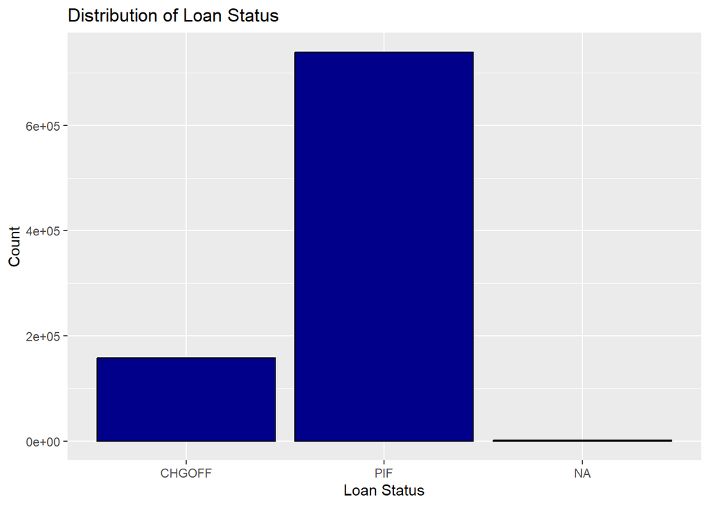

Figure 1: Loan Status (target variable) Plot using original dataset

Thus, considering the large amount of observations in my dataset and in order to deal with the imbalance discussed before, I decided to downsample my data by focusing on the target variable, the loan status. This variable has two categories: “Charged Off” (CHGOFF) or “Paid in Full” (PIF). Thus, I consider 15,000 observations for each category, achieving the downsample of my dataset to 30,000 observations. This introduced an artificial balance of the binary target variable, as seen in Figure 2, which will address the initial imbalance and missingness of the target variable in the initial data distribution .

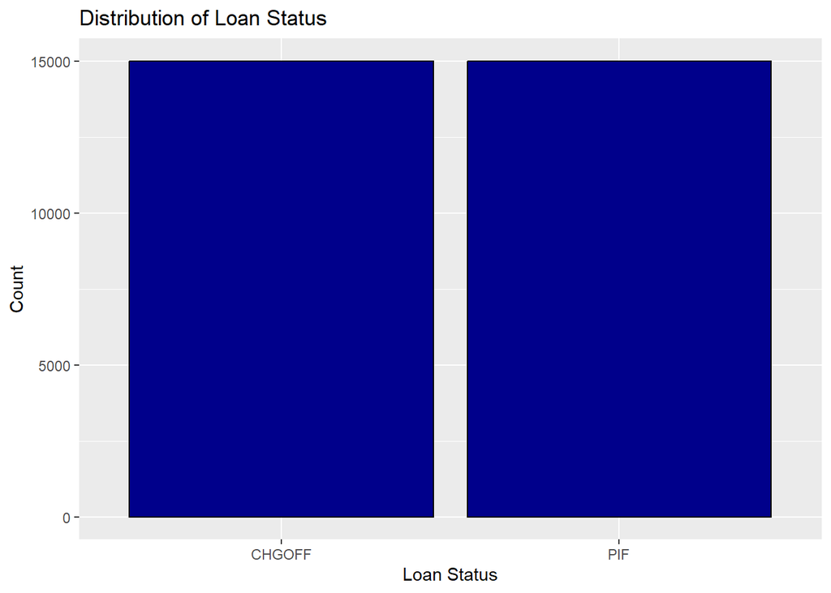

Figure 2: Loan Status (target variable) Plot using downsampled dataset

### Downsampled data overview

The downsampled dataset comprises 30,000 observations. It encompasses 27 variables capturing various attributes. Of these variables, 5 are character type, 3 are date type, 3 are factor type, and 16 are numeric type. There is some missingness across the variables, the variable which the highest amount of missing values is the charge-off date, with about 50.3% of values missing. Nevertheless, the priority, the target variable have a completeness rate of 100%.

## Methods

The following aspects where considering in the methodology to approach this project.

### Type of prediction problem

This project focus on a classification problem where the goal is to classify loan applications into two categories: “Approved” or “Rejected” based on the loan status variable, the target variable, which indicates whether the loan is “Charged Off” (CHGOFF) or “Paid in Full” (PIF).

### Data Splitting

The data is initially split into training and testing sets using a 75/25 ratio. This means that 75% of the data conforms training data which is used to train the machine learning model. It serves as the basis for the model to learn the patterns and relationships between the input features and the target variable, the loan status. While, 25% of the data that was not used during training will conform the testing data. The best model will then make predictions on this data, and these predictions will be compared against the actual outcomes to assess how well the model generalizes to new, unseen data.

Stratified splitting is employed in this project to ensure proportional representation of the target variable, which is the loan status, in both the training and testing datasets.

### Models

##### 1. Naive Bayes:

It is chosen as one of the models due to its simplicity and efficiency, making it suitable for initial exploration of the data.

##### 2. Binary Logistic Regression:

This model serves as a baseline model for comparison, given its simplicity and interpretability. By estimating the probability of loan approval based on input features, logistic regression can provide valuable insights into the relative importance of predictors and their impact on the loan approval decision.

##### 3. Elastic Net:

This regularized regression method that combines the penalties of both L1 (Lasso) and L2 (Ridge) regularization is useful to deal with high-dimensional data and multicollinearity.

Parameters to be tuned:

- Penalty: The penalty parameter controls the balance between L1 and L2 regularization. It will be tuned over a range of values.

##### 4. K-Nearest Neighbors (KNN):

KNN is included to capture potential non-linear relationships between features and loan approval status. In scenarios where decision boundaries are complex, KNN can provide a flexible and intuitive approach to classification tasks.

Parameters to be tuned:

- Number of neighbors (k): Determines the number of nearest neighbors to consider when making predictions. It will be tuned over a range of values.

##### 5. Boost Trees:

It is an ensemble learning model that combines multiple weak learners (typically decision trees) to create a strong predictive model. It iteratively builds trees, focusing on the mistakes of the previous iterations.

Parameters to be tuned:

- Number of trees: The number of trees to include in the boosting process.
- Learning rate: Controls the contribution of each tree to the final model. It will be tuned over a range of values.

##### 6. Random Forest:

It is another ensemble learning method that constructs a multitude of decision trees at training time and outputs the class that is the mode of the classes of the individual trees.

Parameters to be tuned:

- Number of variables randomly sampled as candidates at each split.
- Minimum node size: The minimum number of data points allowed in a terminal node. It will be tuned over a range of values.

### Recipes

For this project there are two main recipes are considered Recipe 1, consider the baseline recipe, and a more complex one call Recipe 2. The baseline recipe involves steps such as removing irrelevant predictors, handling unknown levels, and one-hot encoding categorical variables. While Recipe 2 includes additional preprocessing steps to handle correlated predictors and normalize the numeric predictors. Both recipes will be used in the models’ fittings in order to know which one performs better.

For the naive Bayes model, two separate recipes are used due to the inability to use a processioning step to one-hot encoding categorical variables. The baseline recipe for this model is simpler, while the enhanced recipe includes additional preprocessing steps such as recoding factors and normalization.

### Metric for Model Comparison

The metric used for model comparison and selection accuracy, as it provides a straightforward measure of each model’s overall performance in classifying loan applications correctly.

### Resampling Technique

The resampling technique used in this project is cross-validation, which is a method for estimating the performance of a predictive model by repeatedly splitting the dataset into training and testing sets. Specifically, the dataset is initially divided into 10 folds. Each fold serves as a holdout set for testing the model, while the remaining data is used for training. This process is repeated 5 times. The data is divided into folds at random within each repetition, resulting in a total of 50 model evaluations

Stratified cross-validation ensures that the distribution of the target variable, the loan status, is preserved across the folds, enhancing the reliability of the evaluation. By repeating the cross-validation process multiple times, any variability due to the random selection of folds is reduced, leading to a more stable and reliable estimate of the model’s performance.

## Model Building & Selection

The models analysis and selection will be based on the accuracy of their performances.

| Model | Metric | Mean | Num Models | Std Error |
| --- | --- | --- | --- | --- |
| Naive Bayes | accuracy | 0.6095911 | 50 | 0.0024469 |
| Knn | accuracy | 0.9039822 | 50 | 0.0007896 |
| Elastic Net | accuracy | 0.9879200 | 50 | 0.0003138 |
| Binary Logistic | accuracy | 0.9879733 | 50 | 0.0003132 |
| Boost Tree | accuracy | 0.9931733 | 50 | 0.0006003 |
| Random Forest | accuracy | 0.9952622 | 50 | 0.0001749 |

Figure 3: Best Estimated Accuracy per model using baseline recipe (Recipe 1)

In Figure 3 it is seen that the model with worst performance is Naive Bayes with a mean 0.610 based on the accuracy as metric. While the best model performing is Random Forest with a mean of 0.995.

| Model | Metric | Mean | Num Models | Std Error |
| --- | --- | --- | --- | --- |
| Naive Bayes | accuracy | 0.6124356 | 50 | 0.0024339 |
| Knn | accuracy | 0.9043733 | 50 | 0.0009141 |
| Elastic Net | accuracy | 0.9877867 | 50 | 0.0003248 |
| Binary Logistic | accuracy | 0.9878489 | 50 | 0.0003347 |
| Boost Tree | accuracy | 0.9940267 | 50 | 0.0002403 |
| Random Forest | accuracy | 0.9942667 | 50 | 0.0002118 |

Figure 4: Best Estimated Accuracy per model using a more complex recipe (Recipe 2)

In Figure 4 it is seen that the model with worst performance is Naive Bayes with a mean 0.612 based on the accuracy as metric. While the best model performing is Random Forest with a mean of 0.994.

### Best parameters for each model

The best performance of each model between the two recipes will be selected, and from them the best parameters will be determined for each and analysed.

#### 2. K-Nearest Neighbors

The best number of neighbors for the KNN model is 5, compared when it is set to 10. This indicates that a lower value for neighbors which led to more localized decision boundaries and a better performance.

#### 3. Boosted Trees

The number of variables randomly sampled at each split (`mtry`) that performed best when building the trees is 11 compared when it is set to 10. This means that higher `mtry` value typically leads to more diverse trees, potentially capturing a wider range of features and increasing the model’s ability to generalize.

The best minimum amount of observations (`min_n`) required in a terminal node of the tree is 16 compared to when it is set to 600. This indicates a lower `min_n` allows for more splits, potentially capturing finer details and nuances in the data.

Finally, both configurations have a best learning rate of 1.00, which means that the contribution of each tree in the boosting ensemble is not scaled. It would be recommend to explore higher learning rates can lead to faster convergence, while keeping in mind that it could also increase the risk of overfitting.

#### 4. Random Forest

The best number variables sampled at each split (`mtry`) when growing trees in a Random Forest, is 7 compared when it is set to 15. This means that a lower `mtry` value can lead to more diverse trees, potentially capturing a broader range of features that would improve the model performance.

The minimum number of observations (`min_n`) required in a terminal node of the tree that performed best when is 5 compared when it is set to 27. This suggests that a lower `min_n` value allows for more splits, which serves to the advantage to the random forest model’s performance. However, setting it too low might lead to overfitting.

### Recipes impact on methods’ performances

Both recipes show consistent performance across different model types, with small standard errors for each metric. This suggests that the common preprocessing steps (such as removing certain columns and handling unknowns) benefit the stability of the model performance.

Indeed, Recipe 2 includes additional preprocessing steps compared to Recipe 1, such as removing highly correlated predictors and normalizing numeric predictors. However, these additional steps do not seem to significantly improve the overall model performance based on the accuracy metric. As shown in Figure 3 and Figure 4, the mean accuracy values for each model type in Recipe 2 are quite similar to those in Recipe 1. This suggests that the added complexity in preprocessing may not always translate into better predictive performance, at least based on the evaluation metric of accuracy.

Across both recipes, certain model types consistently perform better than others. Specifically, the Boost Tree and Random Forest models tend to have higher accuracy compared to Naive Bayes and KNN models. This is not surprising since the ensemble-based models (Boost Tree and Random Forest) are more effective in capturing the complex relationships in the data compared to simpler models like Naive Bayes and KNN.

## Final Model Analysis

To assess the Random Forest performance the following metrics were considered: confusion matrix, accuracy and the receiver operating characteristic curve.

### Confusion Matrix

| Prediction | Truth CHGOFF | Truth PIF |
| --- | --- | --- |
| CHGOFF | 3742 | 8 |
| PIF | 30 | 3720 |

Figure 5: Confusion Matrix

The values displayed in Figure 5 are interpreted as it follows:

- True Positives (TP):

The model correctly predicted 3,742 instances as Charged Off (CHGOFF). These are the instances where the model predicted that the loans would be charged off, and they were indeed charged off.

- False Negatives (FN):

The model incorrectly predicted 30 instances as Paid In Full (PIF) when they were actually Charged Off (CHGOFF). These are the instances where the model failed to predict that the loans would be charged off when they actually were.

- False Positives (FP):

The model incorrectly predicted 8 instances as Charged Off (CHGOFF) when they were actually Paid In Full (PIF). These are the instances where the model predicted that the loans would be charged off, but they were actually paid in full.

- True Negatives (TN):

The model correctly predicted 3,720 instances as “PIF” Paid In Full (PIF). These are the instances where the model predicted that the loans would be paid in full, and they were indeed paid in full.

Overall, based on this confusion matrix, the random forest model demonstrates high accuracy, precision, and recall, indicating strong performance in predicting both Charged Off and Paid In Full classes.

### Accuracy

Figure 6 shows the accuracy of the final model,the Random Forest model, is 0.9949333. This indicates that the model performed exceptionally well on the test dataset, meaning that it correctly predicted the outcome for approximately 99.49% of the instances in the test dataset.

| Metric | Estimate |
| --- | --- |
| accuracy | 0.9949333 |

Figure 6: Best Model Accuracy

### Receiver Operating Characteristic (ROC) Curve

As evidenced in Figure 7, the area under the ROC curve (AUC) is close to 1. This indicates that the model has excellent discriminatory power, meaning it can effectively distinguish between the two classes, in this case, Charged Off and Paid in Full.

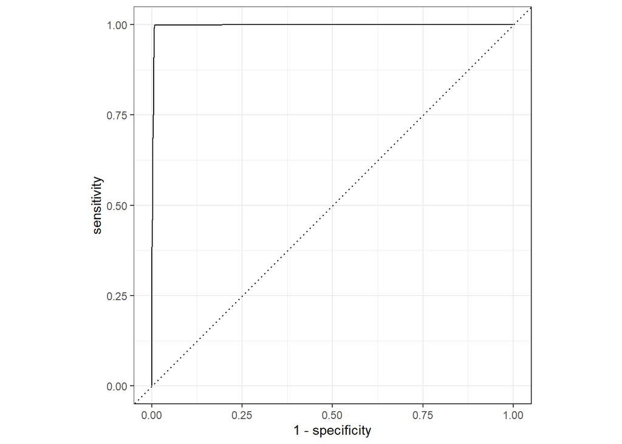

Figure 7: ROC (Receiver Operating Characteristic Curve)

The near-perfect balance between sensitivity and specificity implies that the model effectively balances between correctly identifying positive instances and minimizing false positives, making it highly reliable and suitable when classifying the loan status.

### Does the effort of building a predictive model really pay off?

In the context of loan application approval, accuracy is crucial for making the right decisions about approving or rejecting applications. The random forest model’s higher accuracy (0.9949333) compared to the baseline logistic model (0.9879733) indicates a more precise prediction capability. This difference suggests that the random forest model can better differentiate between applicants who should be approved and those who shouldn’t, reducing the risk of approving risky loans while also minimizing the rejection of viable applicants.

Moreover, the practical implications of the chosen model’s predictions are significant in loan approval decisions. Approving a risky applicant (false positives) can lead to financial losses due to loan defaults, while rejecting a viable applicant (false negatives) can result in missed business opportunities and potential customer dissatisfaction. Therefore, the model’s ability to minimize these errors is crucial for the financial health and customer satisfaction of the Small Business Administration (SBA).

Hence, considering the context of loan application approval, the significant improvement in accuracy provided by the random forest model suggests that the effort invested in building it is likely justified.

## Conclusions

Through this comprehensive data exploration, methodical model building, and rigorous evaluation, the following conclusions have been drawn:

- Even though Recipe 2 included additional preprocessing steps compared to Recipe 1, such as handling correlated predictors and normalizing numeric predictors, the improvement in model performance was marginal. This suggests that the added complexity may not always translate into significantly better predictive performance.
- While Recipe 2 included additional preprocessing steps, it did not lead to a substantial improvement in model performance compared to Recipe 1. Thus, the choice of model type appears to have a larger impact on performance, with ensemble-based models generally outperforming simpler models.
- Random Forest consistently emerged as the top-performing model, outperforming other models in terms of accuracy. Its ability to capture complex relationships in the data contributed to its superior predictive performance.
- The Random Forest model’s high accuracy and excellent discriminatory power would significant practical implications for loan approval decisions. Its ability to accurately classify loan applications as “Charged Off” or “Paid in Full” would minimize the risk of approving risky loans, while also ensuring that viable applicants are not unfairly rejected.

Future work and next steps may involve exploring additional features or alternative modeling techniques to further enhance predictive performance. I would also suggest investigating the generalization of the best model, the random forest, across different geographical regions or loan types, since it could broaden its applicability and relevance in diverse contexts. Overall, this project lays a solid foundation for continued research and innovation in the area of loan approval prediction modeling.

## References

Toktogaraev, M. (2022). “Should This Loan be Approved or Denied? [Data set]. Kaggle. https://www.kaggle.com/datasets/mirbektoktogaraev/should-this-loan-be-approved-or-denied?select=Should+This+Loan+be+Approved+or+Denied+A+Large+Dataset+with+Class+Assignment+Guidelines.pdf